# Prosper Loan Data Exploration

## By Abhishek Tiwari

Date 18/06/2020

## Loan status

**Observation 1:**

- Most of the loans in the data set are actually current loans.
- Past due loans are split in several groups based on the length of payment delay.
- Other big part is completed loans, defaulted loans compromise a minority, however chargedoff loans also comporomise a substanial amount.

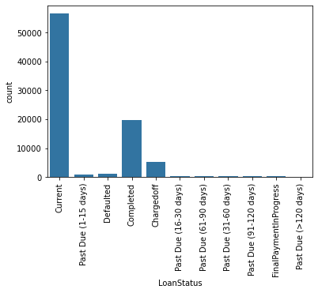

```python
# setting color
base_color = sns.color_palette()[0]
plt.xticks(rotation=90)
sns.countplot(data = target_df, x = 'LoanStatus', color = base_color);
```

## Employment Status

**Observation 2:**

- The majority of borrowers are employed and all other categories as small part of borrowers.
- In small Group full time has highest, after that self empolyed are there and so on.

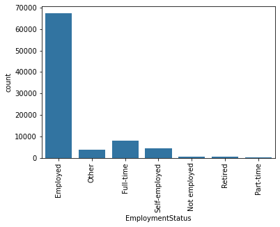

```python
sns.countplot(data = target_df, x = 'EmploymentStatus', color = base_color);
plt.xticks(rotation = 90);
```

## Stated Monthly Income

**Observation 3:**

- With a boundary of mean and 3 times standard deviations distribution of monthly income still has noticeable right skew but now we can see that mode is about 5000.

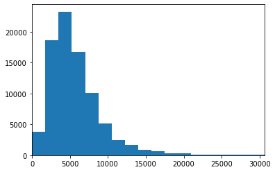

```python
income_std = target_df['StatedMonthlyIncome'].std()
income_mean = target_df['StatedMonthlyIncome'].mean()
boundary = income_mean + income_std * 3
#len(target_df[target_df['StatedMonthlyIncome'] >= boundary])
plt.hist(data=target_df, x='StatedMonthlyIncome', bins=1000);
plt.xlim(0, boundary);
```

## Status and Prosper Rating:

**Observation 1:**

- The `most frequent` rating among defaulted loans is actually `D`.
- And the `most frequent` rating among Completed is also`D`and second highest is A and so on.

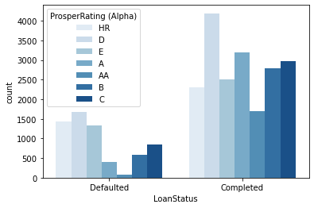

```python
sns.countplot(data = target_df, x = 'LoanStatus', hue = 'ProsperRating (Alpha)', palette = 'Blues');
```

## Credit Start with Listing Category:

**Observation 2:**

- In both of the Graphs the `debt Consolidation` have `most frequency among all of them`.

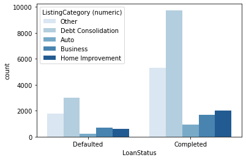

```python
sns.countplot(data = target_df, x = 'LoanStatus', hue = 'ListingCategory (numeric)', palette = 'Blues');
```

## Loan Status and Loan Amount

**Observation 3:**

- As from Above Graph we can state that `defaulted credits` tend to be `smaller` than `completed credits` onces.

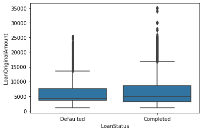

```python
sns.boxplot(data = target_df, x = 'LoanStatus', y = 'LoanOriginalAmount', color = base_color);
```

## Prosper Rating and Employment Status

**Observation 4:**

- Lower ratings seem to have greater proportions of individuals with employment status Not Employed, Self-employed, Retired and Part-Time.

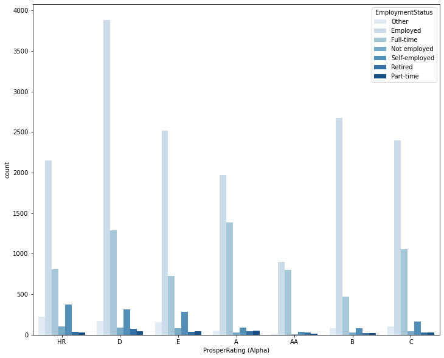

```python
plt.figure(figsize = [12, 10])
sns.countplot(data = target_df, x = 'ProsperRating (Alpha)', hue = 'EmploymentStatus', palette = 'Blues');
```

## Rating, Loan Amount and Loan Status

**Observation 1:**

- Except for the lowest ratings defaulted credits tend to be larger than completed.
- Most of the defaulted credits comes from individuals with low Prosper rating.

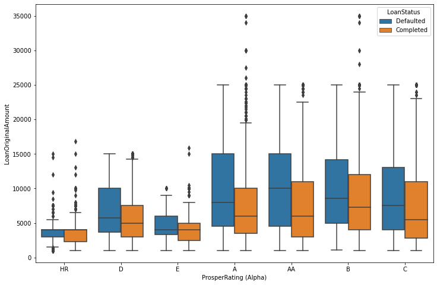

```python
plt.figure(figsize = [12, 8])
sns.boxplot(data=target_df, x='ProsperRating (Alpha)', y='LoanOriginalAmount', hue='LoanStatus');
```

## Relationships between Credit category, Credit rating and outcome of Credit.

**Observation 2:**

- There are 5 graphs in the second one has much up and downs in it other than all of them.
- There is no substantial difference for default rates in different categories broken up by ratings.

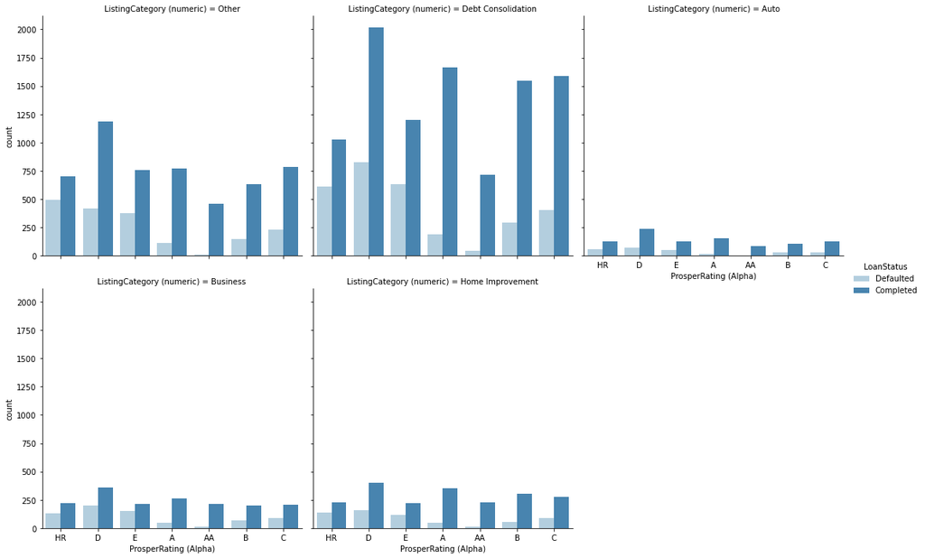

```python
sns.catplot(x = 'ProsperRating (Alpha)', hue = 'LoanStatus', col = 'ListingCategory (numeric)',
              data = target_df, kind = 'count', palette = 'Blues', col_wrap = 3);
```